http://ithelp.ithome.com.tw/articles/10187314

# 前言

經過三天的監督式學習（迴歸與分類）實作，稍微變換一下心情來練習非監督式學習中相當重要的分群演算法。

仔細回想一下，至今練習過的冰紅茶銷量，蛋糕店月銷量，鐵達尼克號乘客的存活與否以及鳶尾花的品種，訓練資料都是有標籤（答案）的，

而非監督式學習與監督式學習最大的不同之處就在於它的訓練資料是沒有標籤（答案）的。

分群演算法的績效衡量簡單明暸：

> 組間差異大，組內差異小。 而所謂的差異指的就是觀測值之間的距離遠近作為衡量， 最常見還是使用歐氏距離（Euclidean distance）。 既然我們又是以距離作為度量，在資料的預處理程序中，與 k-Nearest Neighbors 分類器一樣 我們必須將所有的數值型變數標準化（Normalization），避免因為單位不同，在距離的計算上失真。

我們今天要使用熟悉的鳶尾花資料，採用花瓣（Petal）的長和寬跟花萼（Sepal）的長和寬來練習兩種分群演算法，

分別是 K-Means 與 Hierarchical Clustering。

# K-Means

K-Means 演算法可以非常快速地完成分群任務，

但是如果觀測值具有雜訊（Noise）或者極端值，

其分群結果容易被這些雜訊與極端值影響，適合處理分布集中的大型樣本資料。

我們使用 kmeans() 函數。

```r
# 讀入鳶尾花資料
iris_kmeans <- iris[, -5]

# KMeans 演算法
kmeans_fit <- kmeans(iris_kmeans, nstart=20, centers=3)

# 印出分群結果
kmeans_fit$cluster

# 印出品種看看
iris$Species
```

1. 2

2. 2

3. 2

4. 2

5. 2

6. 2

7. 2

8. 2

9. 2

10. 2

11. 2

12. 2

13. 2

14. 2

15. 2

16. 2

17. 2

18. 2

19. 2

20. 2

21. 2

22. 2

23. 2

24. 2

25. 2

26. 2

27. 2

28. 2

29. 2

30. 2

31. 2

32. 2

33. 2

34. 2

35. 2

36. 2

37. 2

38. 2

39. 2

40. 2

41. 2

42. 2

43. 2

44. 2

45. 2

46. 2

47. 2

48. 2

49. 2

50. 2

51. 3

52. 3

53. 1

54. 3

55. 3

56. 3

57. 3

58. 3

59. 3

60. 3

61. 3

62. 3

63. 3

64. 3

65. 3

66. 3

67. 3

68. 3

69. 3

70. 3

71. 3

72. 3

73. 3

74. 3

75. 3

76. 3

77. 3

78. 1

79. 3

80. 3

81. 3

82. 3

83. 3

84. 3

85. 3

86. 3

87. 3

88. 3

89. 3

90. 3

91. 3

92. 3

93. 3

94. 3

95. 3

96. 3

97. 3

98. 3

99. 3

100. 3

101. 1

102. 3

103. 1

104. 1

105. 1

106. 1

107. 3

108. 1

109. 1

110. 1

111. 1

112. 1

113. 1

114. 3

115. 3

116. 1

117. 1

118. 1

119. 1

120. 3

121. 1

122. 3

123. 1

124. 3

125. 1

126. 1

127. 3

128. 3

129. 1

130. 1

131. 1

132. 1

133. 1

134. 3

135. 1

136. 1

137. 1

138. 1

139. 3

140. 1

141. 1

142. 1

143. 3

144. 1

145. 1

146. 1

147. 3

148. 1

149. 1

150. 3

1. setosa

2. setosa

3. setosa

4. setosa

5. setosa

6. setosa

7. setosa

8. setosa

9. setosa

10. setosa

11. setosa

12. setosa

13. setosa

14. setosa

15. setosa

16. setosa

17. setosa

18. setosa

19. setosa

20. setosa

21. setosa

22. setosa

23. setosa

24. setosa

25. setosa

26. setosa

27. setosa

28. setosa

29. setosa

30. setosa

31. setosa

32. setosa

33. setosa

34. setosa

35. setosa

36. setosa

37. setosa

38. setosa

39. setosa

40. setosa

41. setosa

42. setosa

43. setosa

44. setosa

45. setosa

46. setosa

47. setosa

48. setosa

49. setosa

50. setosa

51. versicolor

52. versicolor

53. versicolor

54. versicolor

55. versicolor

56. versicolor

57. versicolor

58. versicolor

59. versicolor

60. versicolor

61. versicolor

62. versicolor

63. versicolor

64. versicolor

65. versicolor

66. versicolor

67. versicolor

68. versicolor

69. versicolor

70. versicolor

71. versicolor

72. versicolor

73. versicolor

74. versicolor

75. versicolor

76. versicolor

77. versicolor

78. versicolor

79. versicolor

80. versicolor

81. versicolor

82. versicolor

83. versicolor

84. versicolor

85. versicolor

86. versicolor

87. versicolor

88. versicolor

89. versicolor

90. versicolor

91. versicolor

92. versicolor

93. versicolor

94. versicolor

95. versicolor

96. versicolor

97. versicolor

98. versicolor

99. versicolor

100. versicolor

101. virginica

102. virginica

103. virginica

104. virginica

105. virginica

106. virginica

107. virginica

108. virginica

109. virginica

110. virginica

111. virginica

112. virginica

113. virginica

114. virginica

115. virginica

116. virginica

117. virginica

118. virginica

119. virginica

120. virginica

121. virginica

122. virginica

123. virginica

124. virginica

125. virginica

126. virginica

127. virginica

128. virginica

129. virginica

130. virginica

131. virginica

132. virginica

133. virginica

134. virginica

135. virginica

136. virginica

137. virginica

138. virginica

139. virginica

140. virginica

141. virginica

142. virginica

143. virginica

144. virginica

145. virginica

146. virginica

147. virginica

148. virginica

149. virginica

150. virginica

# 績效

分群演算法的績效可以使用 Silhouette 係數或

WSS（Within Cluster Sum of Squares）/BSS（Between Cluster Sum of Squares）。

我們使用 Total WSS（Total Within Cluster Sum of Squares）/Total SS（Total Sum of Squares），這個比例愈低表示績效愈好。

```r
# 讀入鳶尾花資料
iris_kmeans <- iris[, -5]

# KMeans 演算法
kmeans_fit <- kmeans(iris_kmeans, nstart=20, centers=3)
ratio <- kmeans_fit$tot.withinss / kmeans_fit$totss
ratio
```

0.115724748655351

# 如何選擇 k

隨著 k 值的增加，K-Means 演算法的績效一定會愈來愈好，當 k = 觀測值數目的時候，

我們會得到一個組間差異最大，組內差異最小的結果，但這不是我們想要的，

實務上我們讓程式幫忙選擇一個適合的 k。

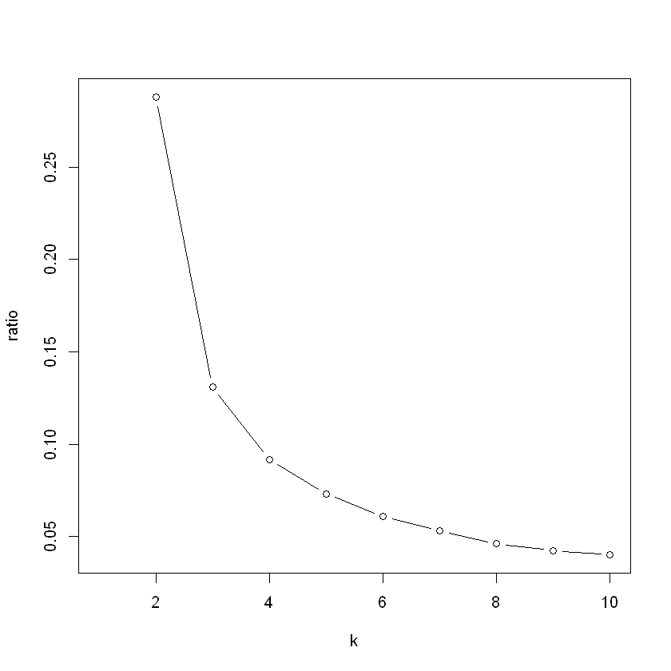

```r
# 讀入鳶尾花資料
iris_kmeans <- iris[, -5]

# 迴圈
ratio <- rep(NA, times = 10)
for (k in 2:length(ratio)) {
  kmeans_fit <- kmeans(iris_kmeans, centers = k, nstart = 20)
  ratio[k] <- kmeans_fit$tot.withinss / kmeans_fit$betweenss
}
plot(ratio, type="b", xlab="k")
```

這也驗證了我們先前的觀察，

setosa 這個品種跟另外兩個品種在花瓣（Petal）的長和寬跟花萼（Sepal）的長和寬有比較大的差異，

因此如果是以 K-Means 分群，可能會將 setosa 歸為一群，versicolor 和 virginica 歸為一群。

# Hierarchical Clustering

與 K-Means 演算法不同的地方在於不需要事先設定 k 值，

Hierarchical Clustering 演算法每一次只將兩個觀測值歸為一類，

然後在演算過程中得到 k = 1 一直到 k = n（觀測值個數）群的結果。

```r
# 讀入鳶尾花資料
iris_hclust <- iris[, -5]

# Hierarchical Clustering 演算法
dist_matrix <- dist(iris_hclust)
hclust_fit <- hclust(dist_matrix, method = "single")
hclust_fit_cut <- cutree(hclust_fit, k = 3)

# 印出分群結果
hclust_fit_cut

# 印出品種看看
iris$Species
```

1. 1

2. 1

3. 1

4. 1

5. 1

6. 1

7. 1

8. 1

9. 1

10. 1

11. 1

12. 1

13. 1

14. 1

15. 1

16. 1

17. 1

18. 1

19. 1

20. 1

21. 1

22. 1

23. 1

24. 1

25. 1

26. 1

27. 1

28. 1

29. 1

30. 1

31. 1

32. 1

33. 1

34. 1

35. 1

36. 1

37. 1

38. 1

39. 1

40. 1

41. 1

42. 1

43. 1

44. 1

45. 1

46. 1

47. 1

48. 1

49. 1

50. 1

51. 2

52. 2

53. 2

54. 2

55. 2

56. 2

57. 2

58. 2

59. 2

60. 2

61. 2

62. 2

63. 2

64. 2

65. 2

66. 2

67. 2

68. 2

69. 2

70. 2

71. 2

72. 2

73. 2

74. 2

75. 2

76. 2

77. 2

78. 2

79. 2

80. 2

81. 2

82. 2

83. 2

84. 2

85. 2

86. 2

87. 2

88. 2

89. 2

90. 2

91. 2

92. 2

93. 2

94. 2

95. 2

96. 2

97. 2

98. 2

99. 2

100. 2

101. 2

102. 2

103. 2

104. 2

105. 2

106. 2

107. 2

108. 2

109. 2

110. 2

111. 2

112. 2

113. 2

114. 2

115. 2

116. 2

117. 2

118. 3

119. 2

120. 2

121. 2

122. 2

123. 2

124. 2

125. 2

126. 2

127. 2

128. 2

129. 2

130. 2

131. 2

132. 3

133. 2

134. 2

135. 2

136. 2

137. 2

138. 2

139. 2

140. 2

141. 2

142. 2

143. 2

144. 2

145. 2

146. 2

147. 2

148. 2

149. 2

150. 2

1. setosa

2. setosa

3. setosa

4. setosa

5. setosa

6. setosa

7. setosa

8. setosa

9. setosa

10. setosa

11. setosa

12. setosa

13. setosa

14. setosa

15. setosa

16. setosa

17. setosa

18. setosa

19. setosa

20. setosa

21. setosa

22. setosa

23. setosa

24. setosa

25. setosa

26. setosa

27. setosa

28. setosa

29. setosa

30. setosa

31. setosa

32. setosa

33. setosa

34. setosa

35. setosa

36. setosa

37. setosa

38. setosa

39. setosa

40. setosa

41. setosa

42. setosa

43. setosa

44. setosa

45. setosa

46. setosa

47. setosa

48. setosa

49. setosa

50. setosa

51. versicolor

52. versicolor

53. versicolor

54. versicolor

55. versicolor

56. versicolor

57. versicolor

58. versicolor

59. versicolor

60. versicolor

61. versicolor

62. versicolor

63. versicolor

64. versicolor

65. versicolor

66. versicolor

67. versicolor

68. versicolor

69. versicolor

70. versicolor

71. versicolor

72. versicolor

73. versicolor

74. versicolor

75. versicolor

76. versicolor

77. versicolor

78. versicolor

79. versicolor

80. versicolor

81. versicolor

82. versicolor

83. versicolor

84. versicolor

85. versicolor

86. versicolor

87. versicolor

88. versicolor

89. versicolor

90. versicolor

91. versicolor

92. versicolor

93. versicolor

94. versicolor

95. versicolor

96. versicolor

97. versicolor

98. versicolor

99. versicolor

100. versicolor

101. virginica

102. virginica

103. virginica

104. virginica

105. virginica

106. virginica

107. virginica

108. virginica

109. virginica

110. virginica

111. virginica

112. virginica

113. virginica

114. virginica

115. virginica

116. virginica

117. virginica

118. virginica

119. virginica

120. virginica

121. virginica

122. virginica

123. virginica

124. virginica

125. virginica

126. virginica

127. virginica

128. virginica

129. virginica

130. virginica

131. virginica

132. virginica

133. virginica

134. virginica

135. virginica

136. virginica

137. virginica

138. virginica

139. virginica

140. virginica

141. virginica

142. virginica

143. virginica

144. virginica

145. virginica

146. virginica

147. virginica

148. virginica

149. virginica

150. virginica

# 績效

```r
library(GMD)

# 讀入鳶尾花資料
iris_hclust <- iris[, -5]

# Hierarchical Clustering 演算法
dist_matrix <- dist(iris_hclust)
hclust_fit <- hclust(dist_matrix)
hclust_fit_cut <- cutree(hclust_fit, k = 3)

# 印出績效
hc_stats <- css(dist_matrix, clusters = hclust_fit_cut)
hc_stats$totwss / hc_stats$totbss

# Dendrogram
plot(hclust_fit)
rect.hclust(hclust_fit, k = 2, border = "red")
rect.hclust(hclust_fit, k = 3, border = "green")
```

[output not shown]

[output not shown]

```
Error in library(GMD): there is no package called 'GMD'
Traceback:

1. library(GMD)
2. stop(txt, domain = NA)
```